# Dismantling the bulk: examining neuronal heterogeneity using single-cell techniques

Sara Linker, Apua Paquola, Roger Lasken, and Keegan Korthauer

8/19/2016

### Welcome to the Festival of Genomics workshop on single-cell analyses

This is an R Markdown document that contains instructions and code for the examples used in todays workshop. The first few steps will check that you have all the packages and data files necessary to carry out all of the analyses.

# Hour 1: Getting Started

### Check that the Brain Atlas data files are present

The following code chunk assumes that Brain Atlas files have been downloaded and placed in a folder in your home directory entitled “FestivalWorkshopSC”. If you have downloaded these files to another location, either create a new folder and move the three .csv data files and one documentation text file there, or substitute the file path to where they are currently located for “~/FestivalWorkshopSC”.

```r
setwd("~/FestivalWorkshopSC/")
file.exists("columns-cells.csv")
```

```
## [1] TRUE
```

```r
file.exists("fpkm_table.csv")
```

```
## [1] TRUE
```

```r
file.exists("rows-genes.csv")
```

```
## [1] TRUE
```

```r
file.exists("README.txt")
```

```
## [1] TRUE
```

If any of the preceding lines return `FALSE`, double check that you have set the correct working directory and that all four download files have been placed in that folder. If they are missing, you can download the files [here](http://celltypes.brain-map.org/api/v2/well_known_file_download/502999251).

### Read the Brain Atlas data files into R

The `read.csv` function in R is useful for reading in .csv (comma-separated value) files. First, we’ll read in the main data file `fpkm_table.csv` to a data frame using this function and check its contents. The extra arguments to this function help to format our object so that we have row and column names, and we use character variables instead of converting to factors. For more details on these arguments, you can type `help(read.csv)`. In the resulting `fpkm` object, we have genes in rows (45,771) and cells in columns (1772).

```r
fpkm <- read.csv("fpkm_table.csv", stringsAsFactors = FALSE, header=TRUE, row.names = 1)
str(fpkm[,1:20]) # restrict to the first 20 columns (cells)
```

```
## 'data.frame':    45771 obs. of  20 variables:
##  $ X497122137: num  6.87 30.38 0.03 0 1.82 ...
##  $ X497122141: num  17.61 0 0 0 4.91 ...
##  $ X497122142: num  0 0 0 0 2.06 0 0 0 0 0 ...
##  $ X497122143: num  0.35 0 1.22 0 3.46 0 0.23 0 0 0 ...
##  $ X497122144: num  1.32 0 0.35 0 2.57 0 0.13 0 0 0 ...
##  $ X497122145: num  0.69 0 0.58 0 2.75 0 0 0 0 0 ...
##  $ X497122146: num  0.44 0 0.38 0 2.47 0 0 0 0 0 ...
##  $ X497122147: num  0.31 0 2.99 0 7.36 0 0 0 0 0 ...
##  $ X497122148: num  8.31 0 2.59 0 6.6 0 0.44 0 0 0 ...
##  $ X497122149: num  5.56 0 0 0 0.65 0 0 0 0 0 ...
##  $ X497122150: num  0.31 0 8 0 4.08 0 0 0 0 0 ...
##  $ X497122151: num  13.79 0 7.75 0 0.44 ...
##  $ X497122152: num  13.9 12.8 14.5 12.2 1.3 ...
##  $ X497122153: num  24.36 0 6.58 0 12.04 ...
##  $ X497122154: num  13.44 0 9.48 0 0 ...
##  $ X497122155: num  9.54 0 1.62 0 1.54 0 0 0 0 0 ...
##  $ X497122156: num  7.1 0 0.45 0 3.47 0 0 0 0 0 ...
##  $ X497122157: num  1.65 0 0 0 1.3 0 0 0 0 0 ...
##  $ X497122158: num  7.89 0 5.45 0 8.47 0 0 0 0 0 ...
##  $ X497122159: num  9.85 0 12.89 0 0.74 ...
```

Next, we’ll read in the metadata files, which contain additional information about the rows and columns of the `fpkm` object. The `rows-genes.csv` file contains 45,771 rows (one for each gene) and 5 columns containing information such as the chromosomal location, gene symbol, and gene description.

```r
genes <- read.csv("rows-genes.csv", stringsAsFactors = FALSE, header = TRUE)
str(genes)
```

```
## 'data.frame':    45771 obs. of  5 variables:
##  $ gene_id       : int  500699669 500699670 500699671 500699672 500699673 500699674 500699675 500699676 500699677 500699678 ...
##  $ chromosome    : chr  "1" "1" "1" "1" ...
##  $ gene_entrez_id: int  497097 100418032 105243853 664792 105242387 105242467 619785 19888 20671 664830 ...
##  $ gene_symbol   : chr  "Xkr4" "Gm18956" "LOC105243853" "Gm7341" ...
##  $ gene_name     : chr  "X Kell blood group precursor related family member 4" "predicted gene, 18956" "uncharacterized LOC105243853" "predicted gene 7341" ...
```

The `columns-cells.csv` file contains 1772 rows (one for each cell) and columns containing information such as age of the donor mouse, targeted brain region, brain slice ID, percentage of reads that mapped, and putative cell subtype.

```r
cells <- read.csv("columns-cells.csv", stringsAsFactors = FALSE, header = TRUE)
str(cells)
```

```
## 'data.frame':    1772 obs. of  22 variables:
##  $ rnaseq_profile_id                                  : int  497122137 497122141 497122142 497122143 497122144 497122145 497122146 497122147 497122148 497122149 ...
##  $ donor_id                                           : int  485247214 485247214 485247214 485247214 485247214 485247214 485247214 485247214 485247214 485247214 ...
##  $ donor_age                                          : chr  "P54" "P54" "P54" "P54" ...
##  $ genotype_driver                                    : chr  "Slc32a1-IRES-Cre" "Slc32a1-IRES-Cre" "Slc32a1-IRES-Cre" "Slc32a1-IRES-Cre" ...
##  $ genotype_reporter                                  : chr  "Ai14" "Ai14" "Ai14" "Ai14" ...
##  $ cell_reporter                                      : chr  "cre reporter positive" "cre reporter positive" "cre reporter positive" "cre reporter positive" ...
##  $ cell_prep_sample_id                                : int  486509295 486509295 486509295 486509295 486509295 486509295 486509295 486509295 486509624 486509624 ...
##  $ sampling_region                                    : chr  "Mouse LGN - Core" "Mouse LGN - Core" "Mouse LGN - Core" "Mouse LGN - Core" ...
##  $ slice_index                                        : int  11 11 11 11 11 11 11 11 13 13 ...
##  $ slice_id                                           : int  486749503 486749503 486749503 486749503 486749503 486749503 486749503 486749503 486749564 486749564 ...
##  $ slice_name                                         : chr  "Slc32a1-IRES-Cre;Ai14-204789.11.01" "Slc32a1-IRES-Cre;Ai14-204789.11.01" "Slc32a1-IRES-Cre;Ai14-204789.11.01" "Slc32a1-IRES-Cre;Ai14-204789.11.01" ...
##  $ cell_id                                            : int  501389972 501389973 501389974 501389975 501389976 501389977 501389978 501389979 501389980 501389981 ...
##  $ rnaseq_profile_total_reads                         : int  3380643 3252488 3309330 3576681 4954087 3920690 3859904 2221764 617242 718808 ...
##  $ rnaseq_profile_percent_reads_aligned_to_mrna       : num  48.7 51.1 48.8 66.7 52.2 45.3 60.7 63.5 63.4 61.8 ...
##  $ rnaseq_profile_percent_reads_aligned_to_ncrna      : num  2.05 3.55 3.63 2.48 3.88 4.01 2.84 3.01 3.05 2.9 ...
##  $ rnaseq_profile_percent_reads_aligned_to_genome_only: num  9.35 16.4 17.7 10.4 16.1 20.4 13.6 12.1 11.5 8.5 ...
##  $ subclass                                           : chr  "Styk1_Xylb" "Styk1_Cdh13_Car10" "Tac1_Gabra4" "Styk1_Xylb" ...
##  $ subclass_order                                     : int  9 7 6 9 7 6 9 9 18 18 ...
##  $ subclass_color                                     : chr  "#FF3030" "#FF6A6A" "#CE1256" "#FF3030" ...
##  $ broad_class                                        : chr  "Gad2_Chrna6" "Gad2_Chrna6" "Gad2_Chrna6" "Gad2_Chrna6" ...
##  $ broad_class_order                                  : int  3 3 3 3 3 3 3 3 4 4 ...
##  $ broad_class_color                                  : chr  "#FF0000" "#FF0000" "#FF0000" "#FF0000" ...
```

More detailed information about the column data in each of these three files can be found in the `README.txt` file. Here is a peek at the contents of that file (here we are only showing the first 30 lines).

```bash
# This is a bash command, to be executed at the command line (not within R);
# Alternatively, simply open the README.txt in your favorite text editor to view its contents
head -30 README.txt
```

```
## =================================
## Mouse dorsal LGN Cell Types study
## =================================
##
## rnaseq_profile_id
##
## RNA sequencing data of single cells isolated from mouse dorsal lateral geniculate nucleus (dLGN) of the thalamus.
##
## The data set includes 1772 single cells collected from dLGN in adult mouse and transcriptionally profiled with RNA sequencing. Additional donor meta-data and broad and subclass labels are available for each cell.
##
## The sequencing results were aligned and aggregated at the gene level using the RSEM algorithm, and FPKM values were calculated.
##
## For more details, please see the Documentation tab in the Cell Types web application.
##
##
## fpkm_table.csv
##  Contains the (row, column) matrix of fpkm values obtained for each (gene, cell).
##  The first row contains the unique identifiers of the RNA-seq profiles of the cells (rnaseq_profile_id)
##  The first column contains the gene unique identifiers (gene_id)
##
##
## columns-cells.csv
##  Contains information about the cells profiled with RNA sequencing
##
##  rnaseq_profile_id
##      Expression profile obtained from aligning the RNA-Seq data to the GRCm38.p3 reference genome.
##
##  donor_id
##      Donor from which the cells were obtained.
##
```

### Check that the desired R packages have been installed

Once a list of desired R packages is finalized, can check that they are installed with

```r
require(scde)     #bioconductor
require(monocle)  #bioconductor
require(sincell)  #bioconductor
require(scDD)     #github
require(ggplot2)  #cran
require(devtools) #cran
```

```r
source("http://bioconductor.org/biocLite.R")
biocLite("monocle")
```

For CRAN packages, for example `devtools`, installation can be done with the following code:

```r
install.packages(devtools)
```

For Github packages, for example `scDD`, installation can be done with the following code:

```r
install.packages("devtools")
devtools::install_github("kdkorthauer/scDD")
```

### Visualize major axes of variation in a PCA plot

```r
# extract top 500 variable genes
gene.var <- apply(fpkm, 1, function(x) var(log(x[x>0])))
fpkm.top500 <- fpkm[which(rank(-gene.var)<=500),]

fpkm.pca <- prcomp(log(fpkm.top500+1),
                   center = TRUE,
                   scale. = TRUE)
summary(fpkm.pca)$importance[,1:5]
```

```
##                             PC1      PC2      PC3      PC4      PC5
## Standard deviation     32.64068 17.78808 7.748475 6.688873 4.845267
## Proportion of Variance  0.60125  0.17856 0.033880 0.025250 0.013250
## Cumulative Proportion   0.60125  0.77981 0.813700 0.838940 0.852190
```

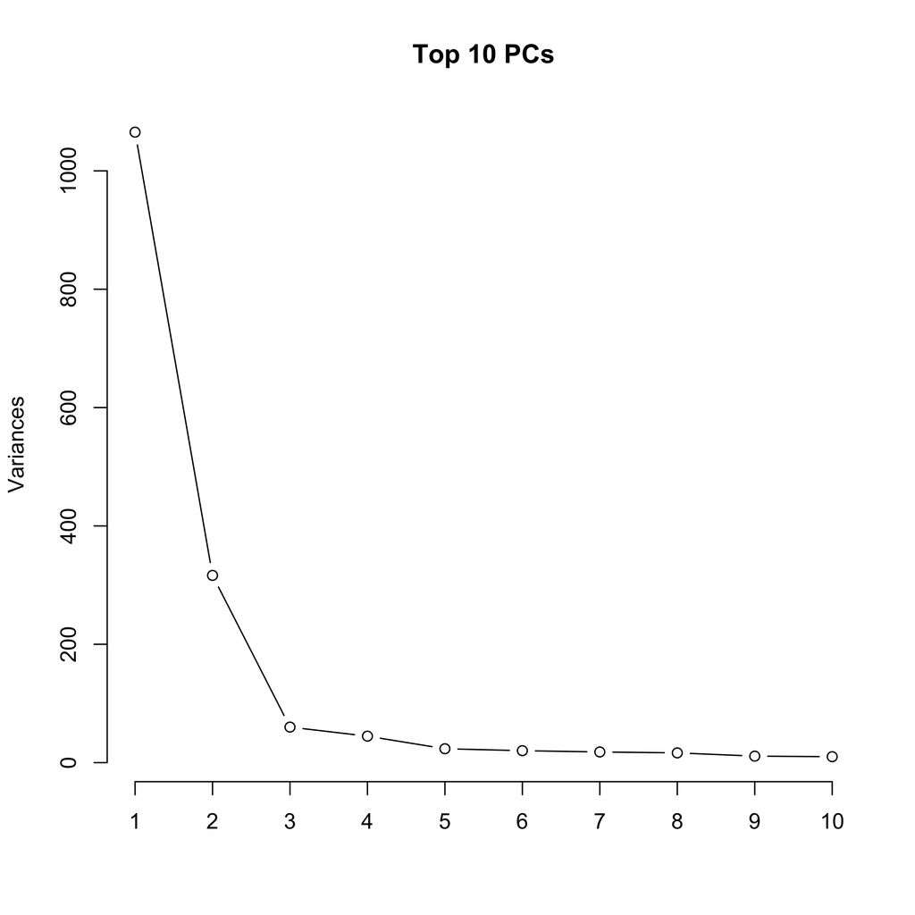

```r
plot(fpkm.pca, type="l", main="Top 10 PCs")
```

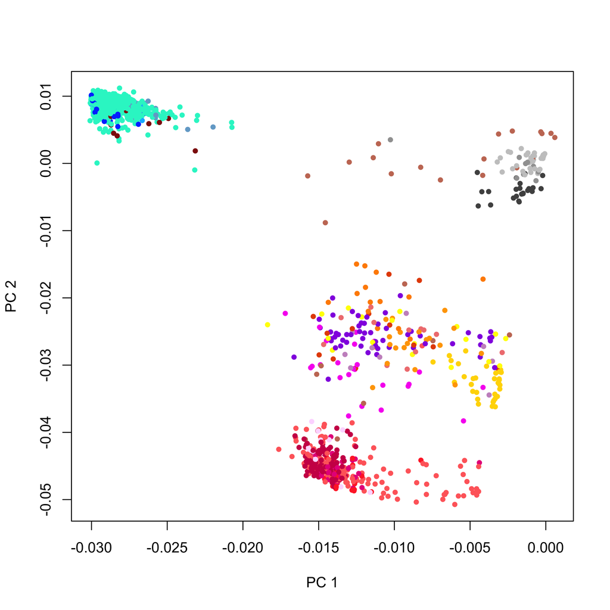

```r
color_class <- rainbow(length(unique(cells$sampling_region)))
# specify col=color_class[as.numeric(factor(cells$sampling_region))]
plot(fpkm.pca$rotation[,1], fpkm.pca$rotation[,2],
      xlab="PC 1", ylab="PC 2", col=cells$subclass_color, pch=20)
```

# Hour 2: Normalization and Quality Control of scRNA-seq

### Quality Control (QC measures)

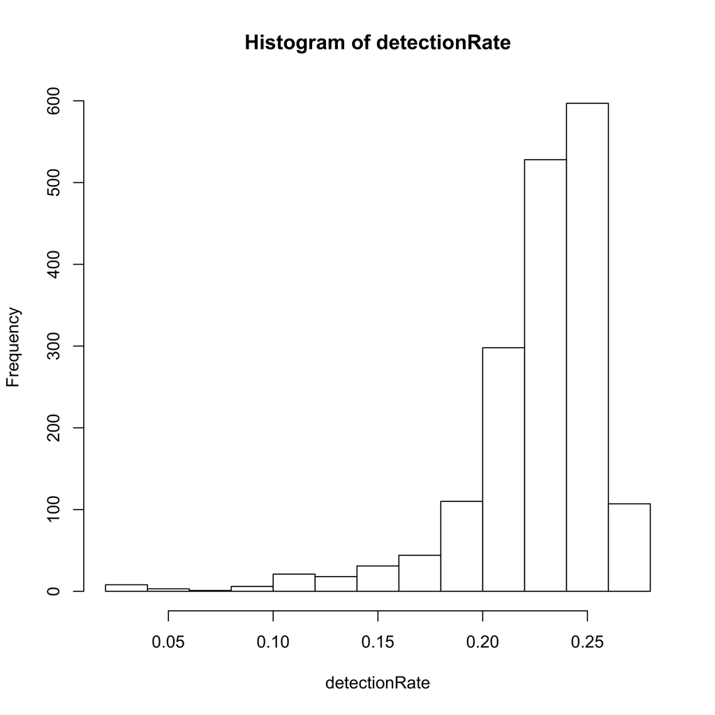

```r
detectionRate <- apply(fpkm, 2, function(x) sum(x > 0) / length(x))
hist(detectionRate)
```

# Hour 3: Analysis Modules

### Identify the highly variable genes

```r
library(sincell)
```

### Identify differentially expressed genes

```r
library(scde)
library(scDD)
```

### Order cells by “Psuedotime” (temporal-spatial variation)

```r
library(monocle)
```

### Identify genes with oscillating expression patterns

```r
library(Oscope)
```